# ps5_Markdown

Mengqi Shi

2023-02-13

1 Load and check data (5pt) You first task is to do a very simple data check: 1. (1pt) For solving the problems, and answering the questions, create a new rmarkdown docu- ment with an appropriate title. See https://faculty.washington.edu/otoomet/info201-book/ r-markdown.html#r-markdown-rstudio-creating.

```r
library(readr)
gapminder <- read_delim("~/Desktop/INFO 201/ps5_Markdown/gapminder.csv")
```

2. (2pt) Load data. How many rows/columns do we have?

```r
nrow(gapminder)
```

```
## [1] 13055
```

```r
ncol(gapminder)
```

```
## [1] 25
```

3. (2pt) Print a small sample of data. Does it look OK? Yes.

```r
head(gapminder, 3)
```

```
## # A tibble: 3 × 25
##   iso3  name  iso2  region sub-r…¹ inter…²  time total…³ ferti…⁴ lifeE…⁵ child…⁶
##   <chr> <chr> <chr> <chr>  <chr>   <chr>   <dbl>   <dbl>   <dbl>   <dbl>   <dbl>
## 1 ABW   Aruba AW    Ameri… Latin … Caribb…  1960   54211    4.82    65.7      NA
## 2 ABW   Aruba AW    Ameri… Latin … Caribb…  1961   55438    4.66    66.1      NA
## 3 ABW   Aruba AW    Ameri… Latin … Caribb…  1962   56225    4.47    66.4      NA
## # … with 14 more variables: youthFemaleLiteracy <dbl>, youthMaleLiteracy <dbl>,
## #   adultLiteracy <dbl>, GDP_PC <dbl>, accessElectricity <dbl>,
## #   agriculturalLand <dbl>, agricultureTractors <dbl>, cerealProduction <dbl>,
## #   fertilizerHa <dbl>, co2 <dbl>, greenhouseGases <dbl>, co2_PC <dbl>,
## #   pm2.5_35 <dbl>, battleDeaths <dbl>, and abbreviated variable names
## #   ¹`sub-region`, ²`intermediate-region`, ³totalPopulation, ⁴fertilityRate,
## #   ⁵lifeExpectancy, ⁶childMortality
```

2 Descriptive statistics (15pt) 1. (3pt) How many countries are there in the dataset? Analyze all three: iso3, iso2 and name.

```r
library(dplyr)
length(unique(gapminder$iso3))
```

```
## [1] 253
```

```r
length(unique(gapminder$iso2))
```

```
## [1] 249
```

```r
length(unique(gapminder$name))
```

```
## [1] 250
```

2. If you did this correctly, you saw that there are more names than iso-2 codes, and there are even more iso3 -codes. What is going on? Can you find it out? The name are not one-on-one, so there are more iso3 and iso2 codes.
1. (5pt) Find how many names are there for each iso-2 code. Are there any iso-2 codes that correspond to more than one name? What are these countries? Namibia.

```r
gapminder%>%
   group_by(iso2, name)%>%
   summarise(result=n(),
          isDubl=ifelse(n()>1,T,F))
```

```
## # A tibble: 250 × 4
## # Groups:   iso2 [249]
##    iso2  name                 result isDubl
##    <chr> <chr>                 <int> <lgl>
##  1 AD    Andorra                  60 TRUE
##  2 AE    United Arab Emirates     60 TRUE
##  3 AF    Afghanistan              60 TRUE
##  4 AG    Antigua and Barbuda      60 TRUE
##  5 AI    Anguilla                  1 FALSE
##  6 AL    Albania                  60 TRUE
##  7 AM    Armenia                  60 TRUE
##  8 AO    Angola                   60 TRUE
##  9 AQ    Antarctica                1 FALSE
## 10 AR    Argentina                60 TRUE
## # … with 240 more rows
```

2. (5pt) Now repeat the same for name and iso3-code. Are there country names that have more than one iso3-code? What are these countries? Hint: two of these entitites are CHANISL and NLD CURACAO.

These are CHANISL, GBM, KOS, and NLD CURACAO

```r
gapminder%>%
   group_by(iso3, name)%>%
   summarise(result=n(),
          isDubl=ifelse(n()>1,T,F))
```

```
## # A tibble: 253 × 4
## # Groups:   iso3 [253]
##    iso3  name                 result isDubl
##    <chr> <chr>                 <int> <lgl>
##  1 ABW   Aruba                    60 TRUE
##  2 AFG   Afghanistan              60 TRUE
##  3 AGO   Angola                   60 TRUE
##  4 AIA   Anguilla                  1 FALSE
##  5 ALA   Åland Islands             1 FALSE
##  6 ALB   Albania                  60 TRUE
##  7 AND   Andorra                  60 TRUE
##  8 ARE   United Arab Emirates     60 TRUE
##  9 ARG   Argentina                60 TRUE
## 10 ARM   Armenia                  60 TRUE
## # … with 243 more rows
```

```r
min(gapminder$time, na.rm = TRUE)
```

```
## [1] 1960
```

```r
max(gapminder$time, na.rm = TRUE)
```

```
## [1] 2019
```

3 CO2 emissions (30pt) Next, let’s analyze CO2 emissions. 1. (2pt) How many missing co2 emissions are there for each year? Analyze both missing CO2 and co2_PC. Which years have most missing data?

```r
library(dplyr)
library(tidyverse)
na_count_co2 <- gapminder %>%
  group_by(time) %>%
  summarize(count_na = sum(is.na(co2)))
na_count_co2
```

```
## # A tibble: 61 × 2
##     time count_na
##    <dbl>    <int>
##  1  1960       60
##  2  1961       60
##  3  1962       58
##  4  1963       57
##  5  1964       51
##  6  1965       51
##  7  1966       51
##  8  1967       51
##  9  1968       51
## 10  1969       51
## # … with 51 more rows
```

```r
na_count_co2PC <- gapminder %>%
  group_by(time) %>%
  summarize(count_na = sum(is.na(co2_PC)))
na_count_co2PC
```

```
## # A tibble: 61 × 2
##     time count_na
##    <dbl>    <int>
##  1  1960       60
##  2  1961       60
##  3  1962       58
##  4  1963       57
##  5  1964       51
##  6  1965       51
##  7  1966       51
##  8  1967       51
##  9  1968       51
## 10  1969       51
## # … with 51 more rows
```

2. (5pt) Make a plot of total CO2 emissions over time for the U.S, China, and India. Add a few more countries of your choice. Explain what do you see.

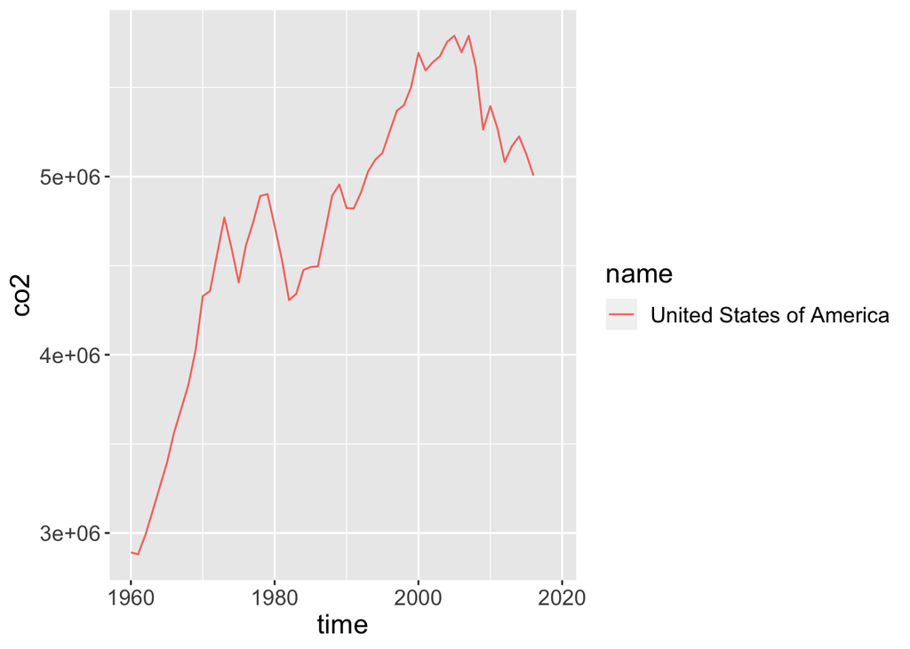

```r
library(ggplot2)
gapminder%>%
  filter(name == 'United States of America') %>%
  ggplot(aes(time, co2, color=name)) +
geom_line() +
  theme(text = element_text(size=15))
```

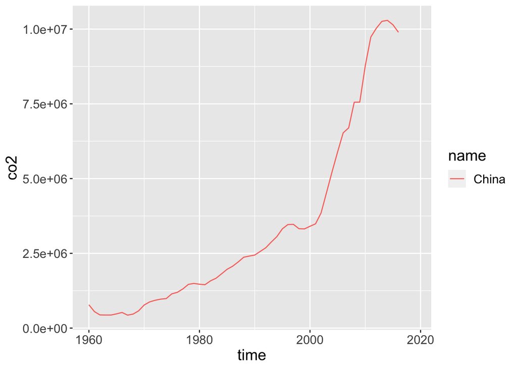

```r
gapminder%>%
  filter(name == 'China') %>%
  ggplot(aes(time, co2, color=name)) +
geom_line() +
  theme(text = element_text(size=15))
```

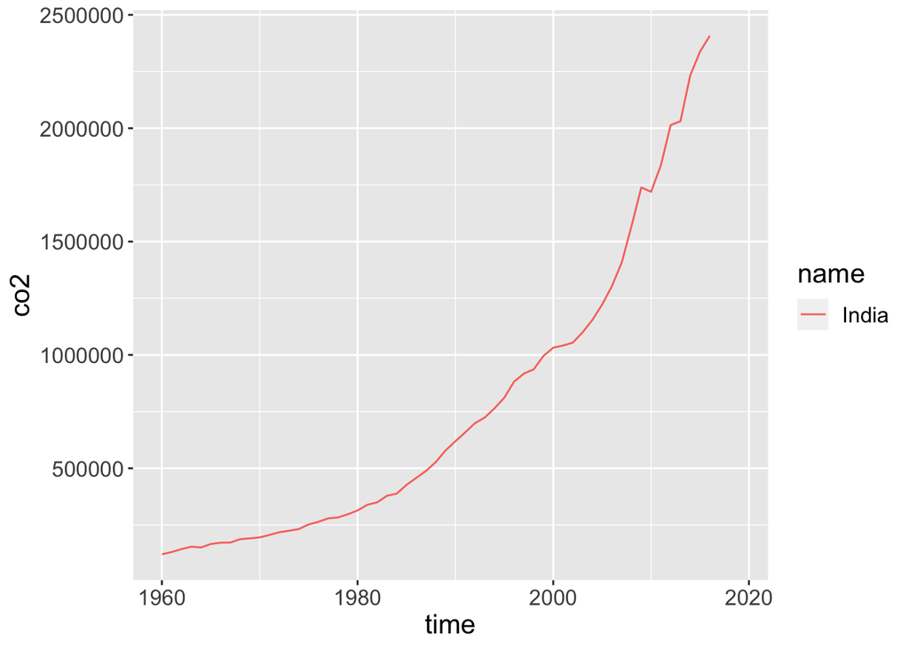

```r
gapminder%>%
  filter(name == 'India') %>%
  ggplot(aes(time, co2, color=name)) +
geom_line() +
  theme(text = element_text(size=15))
```

3. (5pt) Now let’s analyze the CO2 emissions per capita (co2_PC ). Make a similar plot of the same countries. What does this figure suggest?

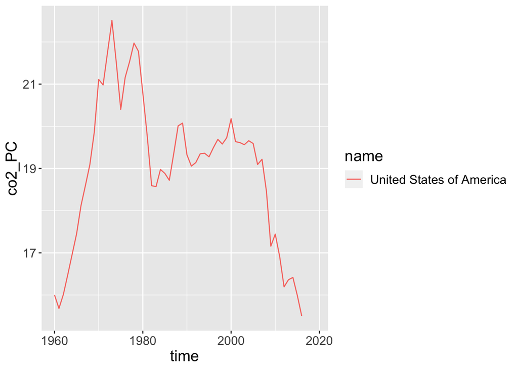

```r
library(ggplot2)
gapminder%>%
  filter(name == 'United States of America') %>%
  ggplot(aes(time, co2_PC, color=name)) +
geom_line() +
  theme(text = element_text(size=15))
```

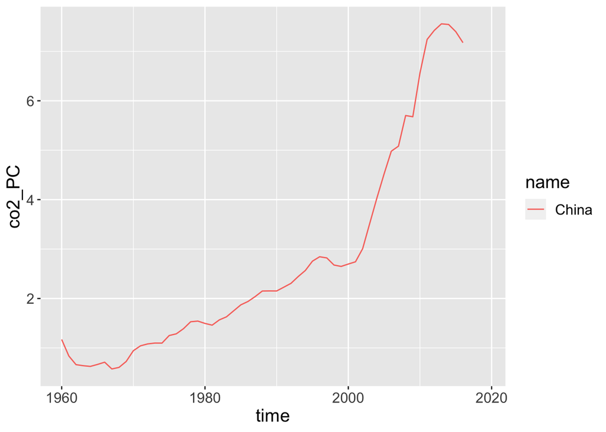

```r
gapminder%>%
  filter(name == 'China') %>%
  ggplot(aes(time, co2_PC, color=name)) +
geom_line() +
  theme(text = element_text(size=15))
```

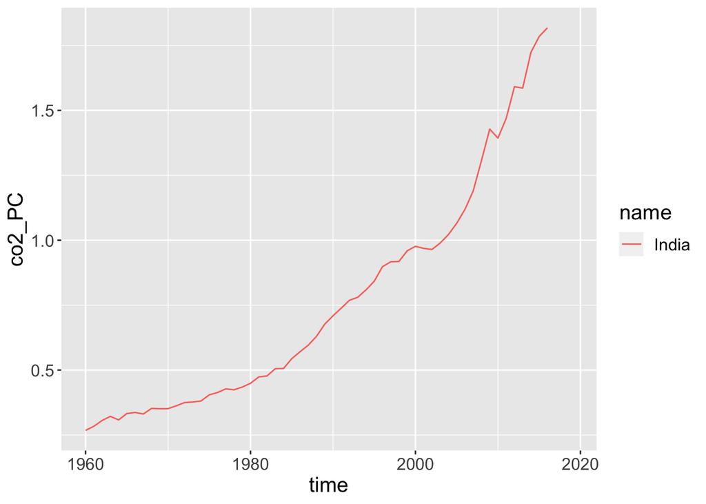

```r
gapminder%>%
  filter(name == 'India') %>%
  ggplot(aes(time, co2_PC, color=name)) +
geom_line() +
  theme(text = element_text(size=15))
```

4. (6pt) Compute average CO2 emissions per capita across the continents (assume region is the same as continent). Comment what do you see. Note: just compute averages over countries and ignore the fact that countries are of different size. Hint: Americas 2016 should be 4.80.

```r
exclude_na <- gapminder %>%
  filter(!is.na(region), !is.na(co2_PC), !is.na(totalPopulation))
exclude_na %>%
  group_by(region,time)%>%
  filter(time == 2016)%>%
  summarize(average = mean(co2_PC))
```

```
## # A tibble: 5 × 3
## # Groups:   region [5]
##   region    time average
##   <chr>    <dbl>   <dbl>
## 1 Africa    2016    1.22
## 2 Americas  2016    4.80
## 3 Asia      2016    6.47
## 4 Europe    2016    6.64
## 5 Oceania   2016    4.57
```

```r
exclude_na %>%
  group_by(region, time)%>%
  filter(time == 1960)%>%
  summarize(average = mean(co2_PC))
```

```
## # A tibble: 5 × 3
## # Groups:   region [5]
##   region    time average
##   <chr>    <dbl>   <dbl>
## 1 Africa    1960   0.291
## 2 Americas  1960   7.15
## 3 Asia      1960   1.74
## 4 Europe    1960   5.77
## 5 Oceania   1960   2.73
```

```r
data <- as.matrix(data.frame(Africa = c(0.291, 1.22),
                             Americas = c(7.15, 4.80),
                             Asia = c(1.74, 6.47),
                             Europe = c(5.77, 6.64),
                             Oceania = c(2.73, 4.57)))
rownames(data) <- c("1960", "2016")
data
```

```
##      Africa Americas Asia Europe Oceania
## 1960  0.291     7.15 1.74   5.77    2.73
## 2016  1.220     4.80 6.47   6.64    4.57
```

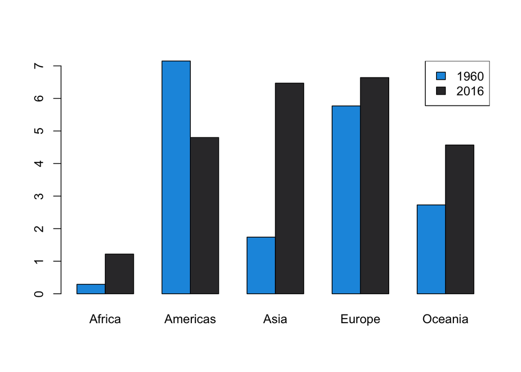

```r
barplot(data,
        col = c("#1B98E0", "#353436"),
        beside = TRUE)
legend("topright",
       legend = c("1960", "2016"),
       fill = c("#1B98E0", "#353436"))
```

```r
##Q6
```

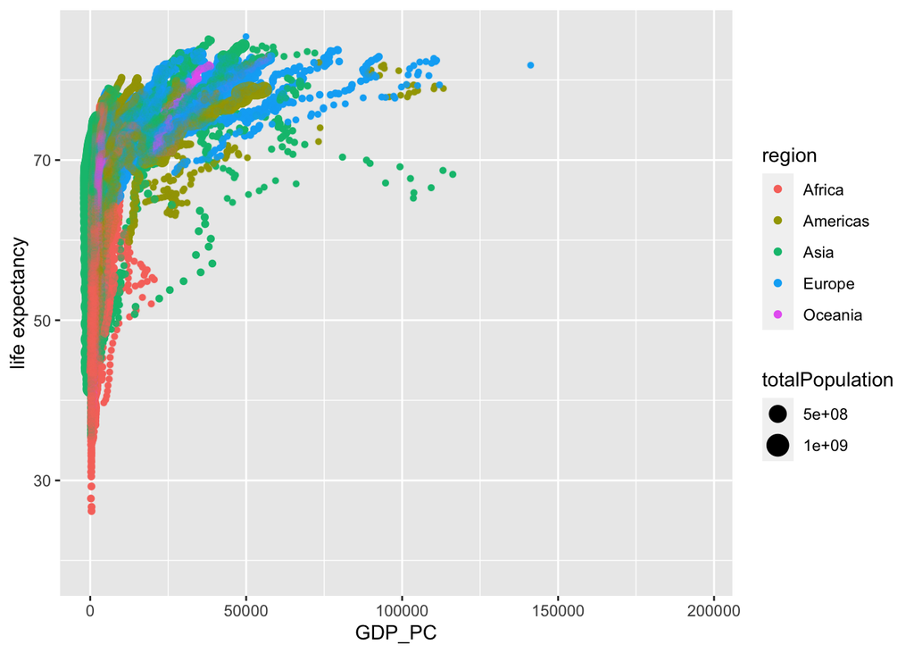

```r
library(ggplot2)
gdp_lifeexpectancy <- ggplot(data = subset(gapminder, !is.na(region), !is.na(name)), aes(x = GDP_PC, y = lifeExpectancy, color = region)) +
  geom_point(aes(size = totalPopulation)) +
  geom_point(alpha = 0.1) +
  xlab("GDP_PC") +
  ylab("life expectancy")
gdp_lifeexpectancy
```

2. (4pt) Make a similar plot, but this time use 2019 data only.

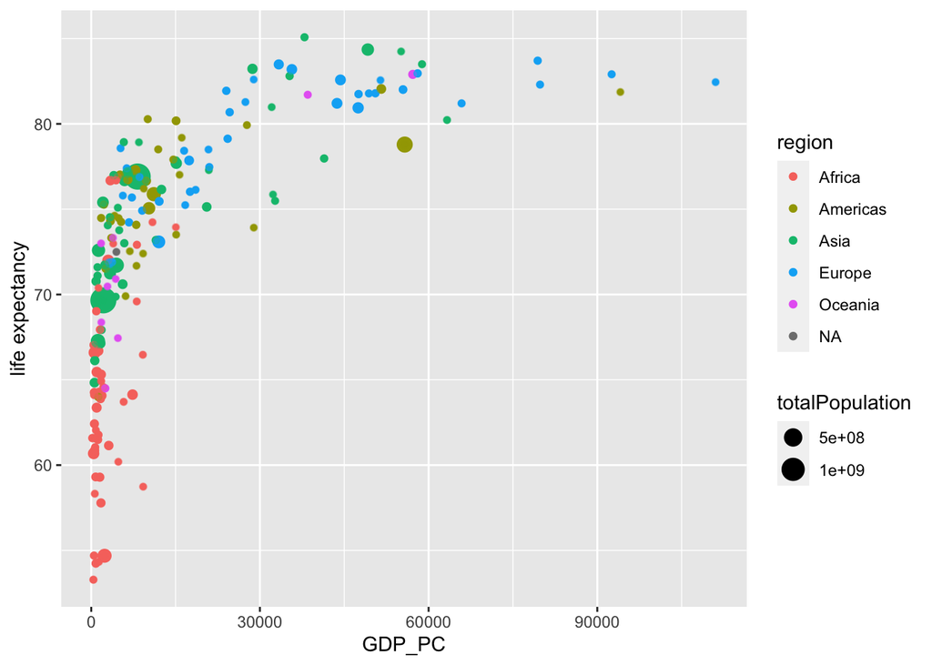

```r
gdp_lifeexpectancy2 <- ggplot(data = filter(gapminder, time == 2019), aes(x = GDP_PC, y = lifeExpectancy, color = region)) +
  geom_point(aes(size = totalPopulation)) +
  geom_point(alpha = 0.4) +
  xlab("GDP_PC") +
  ylab("life expectancy")
gdp_lifeexpectancy2
```

3. (6pt) Compare these two plots and comment what do you see. How has world developed through the last 60 years?
4. (6pt) Compute the average life expectancy for each continent in 1960 and 2019. Do the results fit with what do you see on the figures? Note: here as average I mean just average over countries, ignore the fact that countries are of different size.

```r
exclude_na_life <- gapminder %>%
  filter(!is.na(region), !is.na(lifeExpectancy))
exclude_na_life %>%
  group_by(region, time)%>%
  filter(time == 1960)%>%
  summarize(average = mean(lifeExpectancy))
```

```
## # A tibble: 5 × 3
## # Groups:   region [5]
##   region    time average
##   <chr>    <dbl>   <dbl>
## 1 Africa    1960    41.5
## 2 Americas  1960    58.6
## 3 Asia      1960    51.6
## 4 Europe    1960    68.3
## 5 Oceania   1960    56.4
```

```r
exclude_na_life
```

```
## # A tibble: 11,618 × 25
##    iso3  name  iso2  region   `sub-region` inter…¹  time total…² ferti…³ lifeE…⁴
##    <chr> <chr> <chr> <chr>    <chr>        <chr>   <dbl>   <dbl>   <dbl>   <dbl>
##  1 ABW   Aruba AW    Americas Latin Ameri… Caribb…  1960   54211    4.82    65.7
##  2 ABW   Aruba AW    Americas Latin Ameri… Caribb…  1961   55438    4.66    66.1
##  3 ABW   Aruba AW    Americas Latin Ameri… Caribb…  1962   56225    4.47    66.4
##  4 ABW   Aruba AW    Americas Latin Ameri… Caribb…  1963   56695    4.27    66.8
##  5 ABW   Aruba AW    Americas Latin Ameri… Caribb…  1964   57032    4.06    67.1
##  6 ABW   Aruba AW    Americas Latin Ameri… Caribb…  1965   57360    3.84    67.4
##  7 ABW   Aruba AW    Americas Latin Ameri… Caribb…  1966   57715    3.62    67.8
##  8 ABW   Aruba AW    Americas Latin Ameri… Caribb…  1967   58055    3.42    68.1
##  9 ABW   Aruba AW    Americas Latin Ameri… Caribb…  1968   58386    3.23    68.4
## 10 ABW   Aruba AW    Americas Latin Ameri… Caribb…  1969   58726    3.05    68.8
## # … with 11,608 more rows, 15 more variables: childMortality <dbl>,
## #   youthFemaleLiteracy <dbl>, youthMaleLiteracy <dbl>, adultLiteracy <dbl>,
## #   GDP_PC <dbl>, accessElectricity <dbl>, agriculturalLand <dbl>,
## #   agricultureTractors <dbl>, cerealProduction <dbl>, fertilizerHa <dbl>,
## #   co2 <dbl>, greenhouseGases <dbl>, co2_PC <dbl>, pm2.5_35 <dbl>,
## #   battleDeaths <dbl>, and abbreviated variable names ¹`intermediate-region`,
## #   ²totalPopulation, ³fertilityRate, ⁴lifeExpectancy
```

```r
exclude_na_life %>%
  group_by(region, time)%>%
  filter(time == 2019)%>%
  summarize(average = mean(lifeExpectancy))
```

```
## # A tibble: 5 × 3
## # Groups:   region [5]
##   region    time average
##   <chr>    <dbl>   <dbl>
## 1 Africa    2019    64.1
## 2 Americas  2019    75.8
## 3 Asia      2019    74.6
## 4 Europe    2019    79.4
## 5 Oceania   2019    73.5
```

```r
exclude_na_life
```

[output not shown]

```r
cat("Q4: Yes")
```

```
## Q4: Yes
```

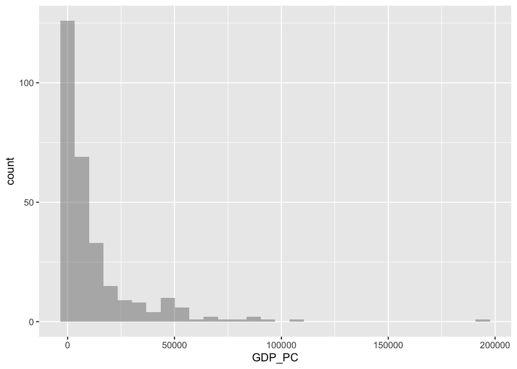

```r
plot_data <-
  gapminder %>%
    filter(time == 1960 | time == 2016)

gdp <- ggplot(plot_data, aes(x = GDP_PC, fill = time)) +
  geom_histogram(position = "identity", alpha = 0.4) +
  xlab("GDP_PC")
gdp
```

```r
gapminder %>%
  filter(time == 2019)%>%
  arrange(lifeExpectancy) %>%
  group_by(name)%>%
  mutate(rank = rank(lifeExpectancy))
```

```
## # A tibble: 217 × 26
## # Groups:   name [214]
##    iso3  name         iso2  region sub-r…¹ inter…²  time total…³ ferti…⁴ lifeE…⁵
##    <chr> <chr>        <chr> <chr>  <chr>   <chr>   <dbl>   <dbl>   <dbl>   <dbl>
##  1 CAF   Central Afr… CF    Africa Sub-Sa… Middle…  2019  4.75e6    4.64    53.3
##  2 TCD   Chad         TD    Africa Sub-Sa… Middle…  2019  1.59e7    5.65    54.2
##  3 LSO   Lesotho      LS    Africa Sub-Sa… Southe…  2019  2.13e6    3.11    54.3
##  4 NGA   Nigeria      NG    Africa Sub-Sa… Wester…  2019  2.01e8    5.32    54.7
##  5 SLE   Sierra Leone SL    Africa Sub-Sa… Wester…  2019  7.81e6    4.17    54.7
##  6 SOM   Somalia      SO    Africa Sub-Sa… Easter…  2019  1.54e7    5.98    57.4
##  7 CIV   Côte d'Ivoi… CI    Africa Sub-Sa… Wester…  2019  2.57e7    4.59    57.8
##  8 SSD   South Sudan  SS    Africa Sub-Sa… Easter…  2019  1.11e7    4.62    57.8
##  9 GNB   Guinea-Biss… GW    Africa Sub-Sa… Wester…  2019  1.92e6    4.40    58.3
## 10 GNQ   Equatorial … GQ    Africa Sub-Sa… Middle…  2019  1.36e6    4.43    58.7
## # … with 207 more rows, 16 more variables: childMortality <dbl>,
## #   youthFemaleLiteracy <dbl>, youthMaleLiteracy <dbl>, adultLiteracy <dbl>,
## #   GDP_PC <dbl>, accessElectricity <dbl>, agriculturalLand <dbl>,
## #   agricultureTractors <dbl>, cerealProduction <dbl>, fertilizerHa <dbl>,
## #   co2 <dbl>, greenhouseGases <dbl>, co2_PC <dbl>, pm2.5_35 <dbl>,
## #   battleDeaths <dbl>, rank <dbl>, and abbreviated variable names
## #   ¹`sub-region`, ²`intermediate-region`, ³totalPopulation, ⁴fertilityRate, …
```

```r
gapminder %>%
  filter(time == 1960)%>%
  arrange(lifeExpectancy) %>%
  group_by(name)%>%
  mutate(rank = rank(lifeExpectancy))
```

```
## # A tibble: 216 × 26
## # Groups:   name [213]
##    iso3  name         iso2  region sub-r…¹ inter…²  time total…³ ferti…⁴ lifeE…⁵
##    <chr> <chr>        <chr> <chr>  <chr>   <chr>   <dbl>   <dbl>   <dbl>   <dbl>
##  1 MLI   Mali         ML    Africa Sub-Sa… Wester…  1960 5263733    6.97    28.2
##  2 YEM   Yemen        YE    Asia   Wester… <NA>     1960 5315355    7.94    29.9
##  3 SLE   Sierra Leone SL    Africa Sub-Sa… Wester…  1960 2317636    6.13    31.6
##  4 SSD   South Sudan  SS    Africa Sub-Sa… Easter…  1960 2842724    6.72    31.7
##  5 GMB   Gambia       GM    Africa Sub-Sa… Wester…  1960  365047    6.25    32.1
##  6 AFG   Afghanistan  AF    Asia   Southe… <NA>     1960 8996973    7.45    32.4
##  7 TLS   Timor-Leste  TL    Asia   South-… <NA>     1960  474532    6.32    33.7
##  8 LBR   Liberia      LR    Africa Sub-Sa… Wester…  1960 1118657    6.41    34.3
##  9 BFA   Burkina Faso BF    Africa Sub-Sa… Wester…  1960 4829288    6.29    34.4
## 10 BTN   Bhutan       BT    Asia   Southe… <NA>     1960  223288    6.64    34.5
## # … with 206 more rows, 16 more variables: childMortality <dbl>,
## #   youthFemaleLiteracy <dbl>, youthMaleLiteracy <dbl>, adultLiteracy <dbl>,
## #   GDP_PC <dbl>, accessElectricity <dbl>, agriculturalLand <dbl>,
## #   agricultureTractors <dbl>, cerealProduction <dbl>, fertilizerHa <dbl>,
## #   co2 <dbl>, greenhouseGases <dbl>, co2_PC <dbl>, pm2.5_35 <dbl>,
## #   battleDeaths <dbl>, rank <dbl>, and abbreviated variable names
## #   ¹`sub-region`, ²`intermediate-region`, ³totalPopulation, ⁴fertilityRate, …
```